# Lorenz Curve and Gini Coefficient with Piketty Data

coop711

2015년 4월 24일

## Data Description

Thomas Piketty가 쓴 **21세기 자본**에는 자본과 소득의 불평등에 대한 다양한 자료가 등장한다. 특히 점유율(share)이라는 관점에서 수집한 자료들이 매우 흥미를 자아낸다. 이 자료들은 [Thomas Piketty - Capital in the 21st century](http://piketty.pse.ens.fr/en/capital21c2) 에서 다운로드받을 수 있다. 이 자료 중에서 불평등과 관련 부분을 가공하여 R에서 쉽게 사용할 수 있도록 하였다.

작업 파일에는 데이터 뿐 아니라 간단한 구조로 lorenz curve를 그리고, gini계수를 계산하는 함수가 저장되어 있다. 먼저 자료부터 확인하자.

```r
load("piketty_gini.rda")
ls()
```

```
## [1] "gini"          "legend.gini"   "lorenz"        "piketty.co"
## [5] "piketty.df"    "piketty.labor" "piketty.total" "x"
```

이 중에서 `piketty.labor`는 노동소득의 점유율, `piketty.co`는 자본소득의 점유율, `piketty.total`은 총소득의 점유율을 나타낸다.

```r
piketty.labor
```

```
##      x  Low Medium High Very.High
## 1 0.00 0.00   0.00 0.00      0.00
## 2 0.50 0.35   0.30 0.25      0.20
## 3 0.90 0.45   0.45 0.40      0.35
## 4 0.99 0.15   0.18 0.23      0.28
## 5 1.00 0.05   0.07 0.12      0.17
```

노동소득의 경우 불평등이 낮은 경우(1970~1980년대 스칸디나비아 국가들)는 하위 50%가 전체 노동소득 중 35%를 가져가고 상위 10%는 20%를 가져가는데 그 중에서 상위 1%가 5%를 가져가고 있다. 불평등이 심해질수록 하위 50%에게 돌아가는 몫은 줄어들고 상위 1%가 가져가는 몫이 늘어난다는 점을 알 수 있다. 불평등이 매우 심한 경우(미국 2030년 예상) 하위 50%에게 돌아가는 몫은 20%에 불과하지만 상위 10%가 가져가는 몫은 무려 45%, 그 중에서도 상위 1%가 가져가는 몫은 17%에 달할 것으로 예상하고 있다. 이는 누적분포로부터 그 구조를 더 명확하게 살필 수 있다.

```r
cbind(x = piketty.labor$x, apply(piketty.labor[, 2:5], 2, cumsum))
```

```
##      x  Low Medium High Very.High
## 1 0.00 0.00   0.00 0.00      0.00
## 2 0.50 0.35   0.30 0.25      0.20
## 3 0.90 0.80   0.75 0.65      0.55
## 4 0.99 0.95   0.93 0.88      0.83
## 5 1.00 1.00   1.00 1.00      1.00
```

자본소득의 집중을 살펴보자

```r
piketty.co
```

```
##      x  Low Medium Med.High High Very.High
## 1 0.00 0.00    0.0     0.00 0.00      0.00
## 2 0.50 0.25    0.1     0.05 0.05      0.05
## 3 0.90 0.45    0.4     0.35 0.25      0.05
## 4 0.99 0.20    0.3     0.35 0.35      0.40
## 5 1.00 0.10    0.2     0.25 0.35      0.50
```

자본소득의 경우 불평등이 낮은 경우(존재한 적 없는 이상국가)는 하위 50%가 전체 노동소득 중 25%를 가져가고 상위 10%는 30%를 가져가는 데 그 중에서 상위 1%가 10%를 가져가고 있다. 불평등이 심해질수록 하위 50%에게 돌아가는 몫은 줄어들고 상위 1%가 가져가는 몫이 확연히 늘어난다는 점을 알 수 있다. 불평등이 매우 심한 경우(1910년대 유럽) 하위 50%에게 돌아가는 몫은 5%에 불과하지만 상위 10%가 가져가는 몫은 90%에 달하고, 그 중에서 상위 1%가 가져가는 몫이 무려 50%에 달한다. 이 또한 누적분포로부터 그 구조를 보다 더 명확하게 살필 수 있다. 일반적으로 노동소득 상위 10%가 전체 노동소득의 25~30%를 받는 반면, 자본소득 상위 10%는 항상전체 부의 50% 이상을 소유한다.

```r
cbind(x = piketty.co$x, apply(piketty.co[, 2:6], 2, cumsum))
```

```
##      x  Low Medium Med.High High Very.High
## 1 0.00 0.00    0.0     0.00 0.00      0.00
## 2 0.50 0.25    0.1     0.05 0.05      0.05
## 3 0.90 0.70    0.5     0.40 0.30      0.10
## 4 0.99 0.90    0.8     0.75 0.65      0.50
## 5 1.00 1.00    1.0     1.00 1.00      1.00
```

총소득의 집중을 살펴보자.

```r
piketty.total
```

```
##      x  Low Medium High Very.High
## 1 0.00 0.00   0.00  0.0      0.00
## 2 0.50 0.30   0.25  0.2      0.15
## 3 0.90 0.45   0.40  0.3      0.25
## 4 0.99 0.18   0.25  0.3      0.35
## 5 1.00 0.07   0.10  0.2      0.25
```

```r
cbind(x = piketty.total$x, apply(piketty.total[, 2:5], 2, cumsum))
```

```
##      x  Low Medium High Very.High
## 1 0.00 0.00   0.00  0.0      0.00
## 2 0.50 0.30   0.25  0.2      0.15
## 3 0.90 0.75   0.65  0.5      0.40
## 4 0.99 0.93   0.90  0.8      0.75
## 5 1.00 1.00   1.00  1.0      1.00
```

```r
x<-piketty.total$x
```

## Plots

이 상황을 그래프로 옮겨보자. x-축에는 소득 순서대로 누적된 사람의 비율율 표시하고 y-축에는 그 사람들이 얼마정도 소득을 축적했는지 누적시켜간다. 따라서 첫 단계는 소득의 누적분포를 구하는 것이다. 우선 노동소득의 `Low` 열에 대하여 `plot()`을 이용하여 누적도표를 그린다. `cumsum(piketty.labor$Low)` 등이 반복해서 나오게 되므로 별도의 R 객체로 저장한다.

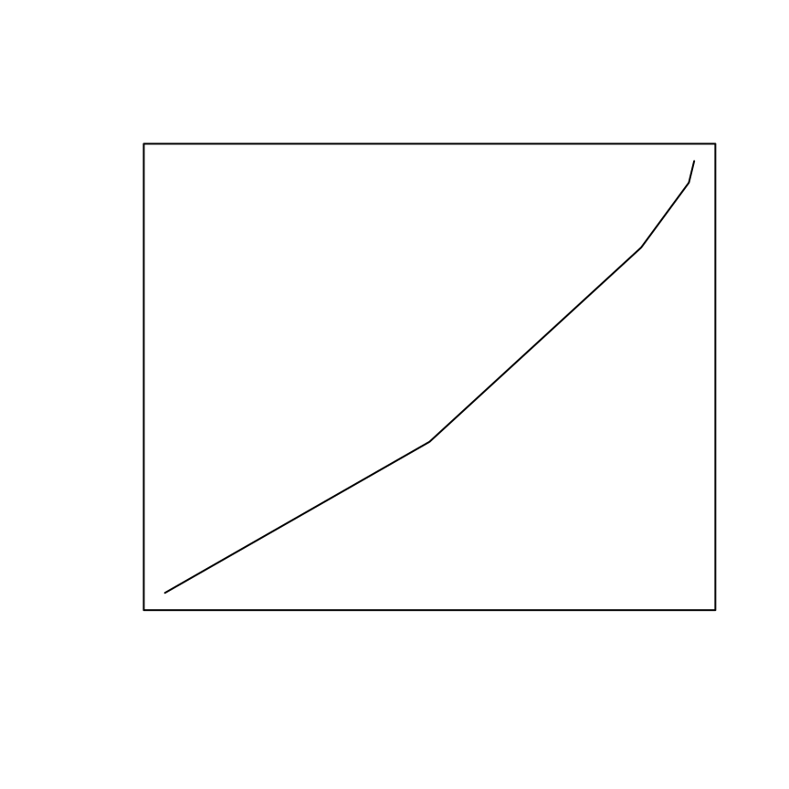

```r
piketty.labor.cum<-apply(piketty.labor[, 2:5], 2, cumsum)
y<-piketty.labor.cum[, 1]
plot(x = x, y = y, type="l", ann=FALSE, xaxt="n", yaxt="n")
```

x축과 y축의 눈금을 표시한다.

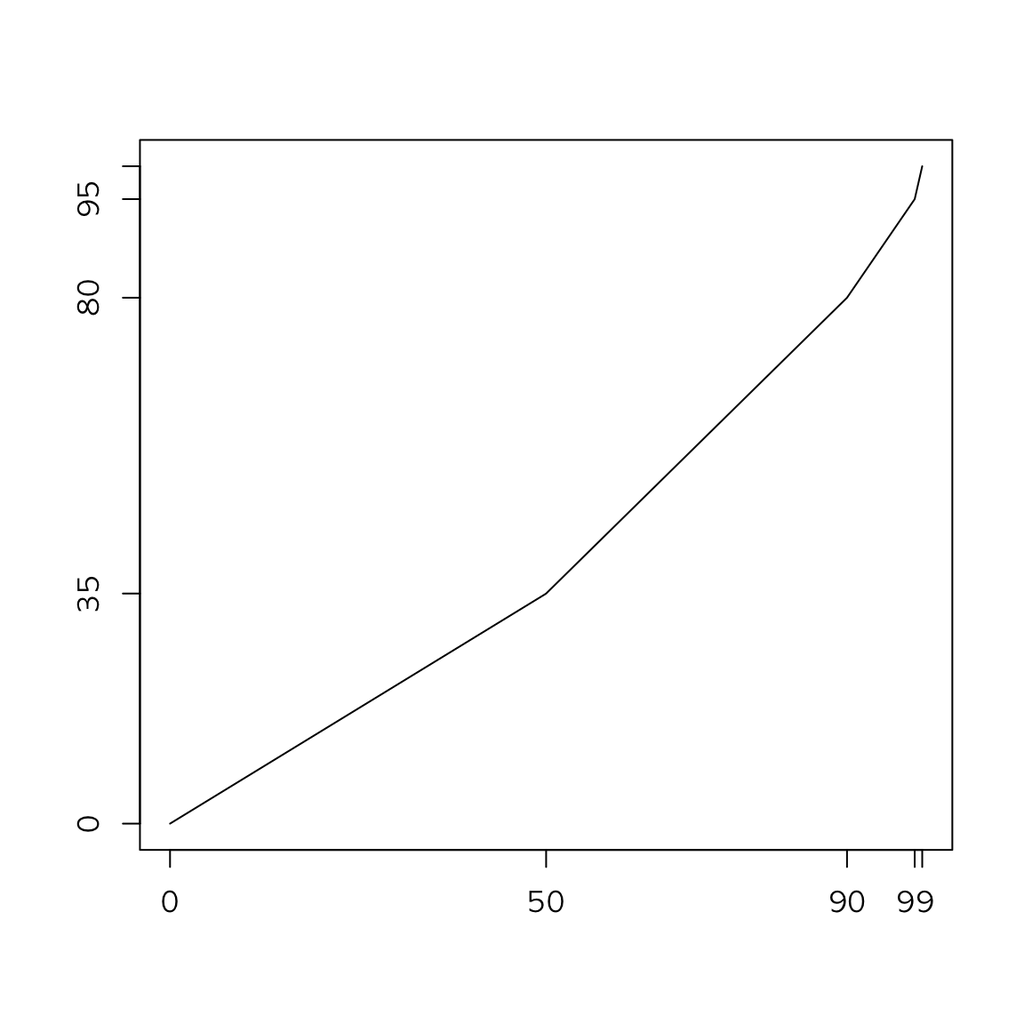

```r
plot(x = x, y = y, type="l", ann=FALSE, xaxt="n", yaxt="n")
axis(side = 1, at = x, labels = paste(x*100))
axis(side = 2, at = y, labels = paste(y*100))
```

완전 평등선이라고 할 수 있는 $y = x$를 같은 영역에 그린다.

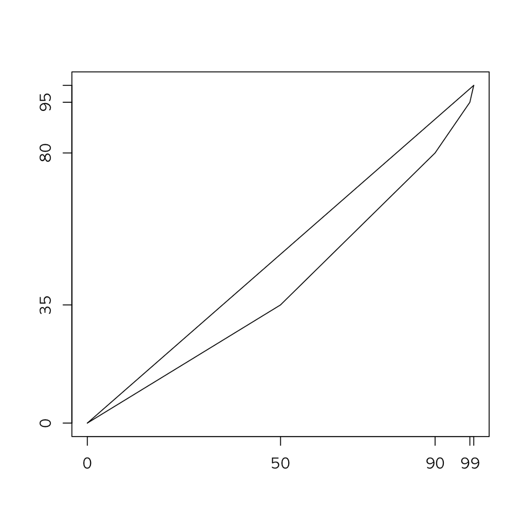

```r
plot(x = x, y = y, type="l", ann=FALSE, xaxt="n", yaxt="n")
axis(side = 1, at = x, labels = paste(x*100))
axis(side = 2, at = y, labels = paste(y*100))
lines(x = x, y = x)
```

x = 0, 0.5, 0.9, 0.99, 1 과 y축의 아래 위에 점선으로 된 격자를 설치하여 윤곽을 쉽게 파악하도록 한다.

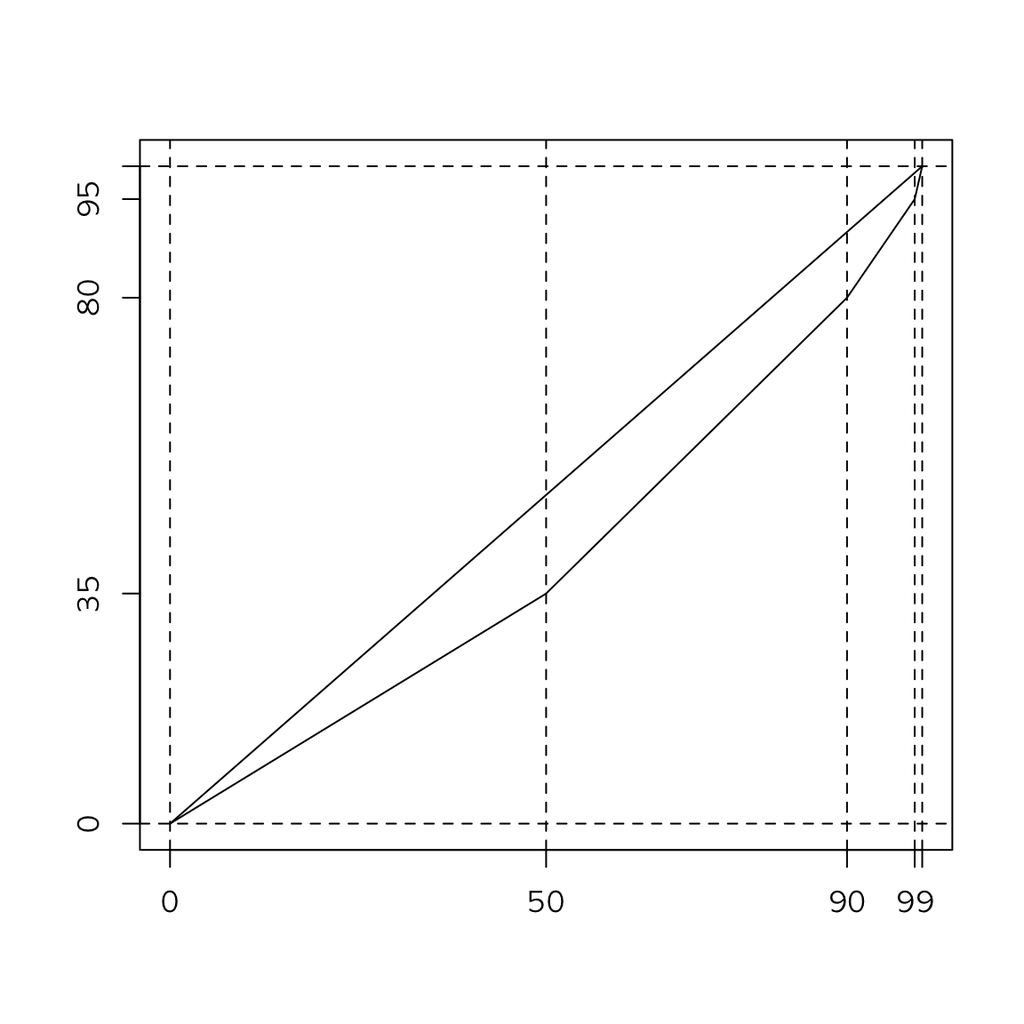

```r
plot(x = x, y = y, type="l", ann=FALSE, xaxt="n", yaxt="n")
axis(side = 1, at = x, labels = paste(x*100))
axis(side = 2, at = y, labels = paste(y*100))
lines(x = x, y = x)
abline(v = x, h = c(0, 1), lty=2)
```

`polygon()`을 이용하여 평등선과 소득누적분포의 차이를 빗금으로 표시한다.

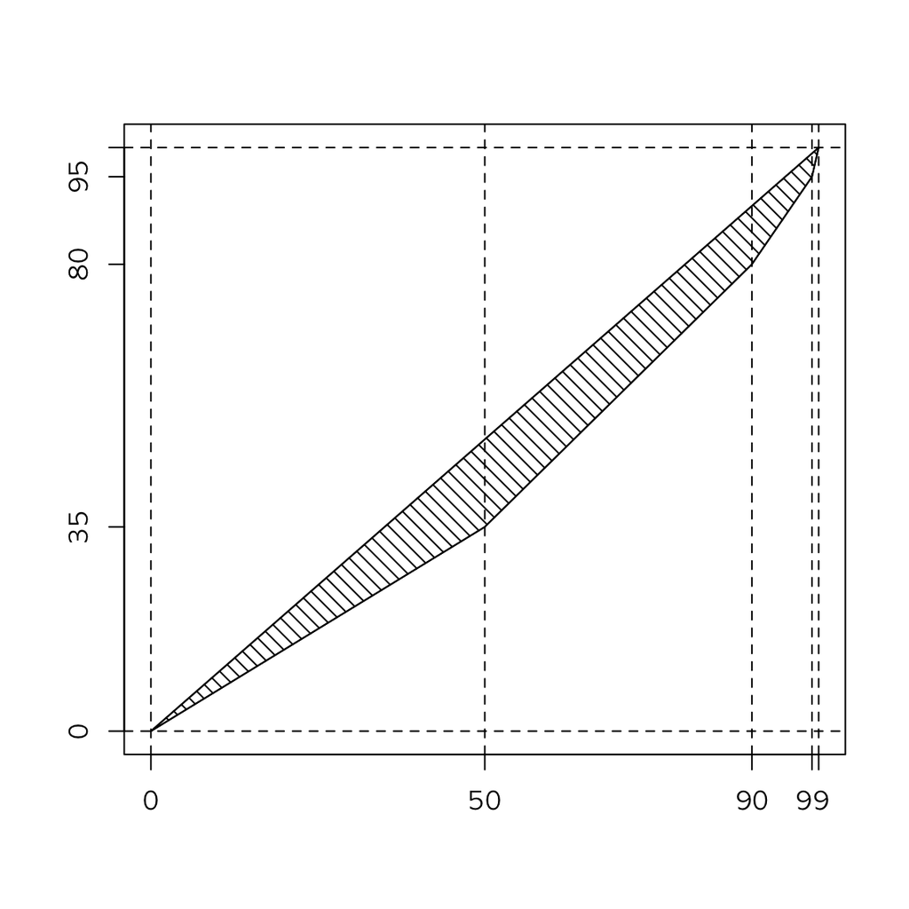

```r
plot(x = x, y = y, type="l", ann=FALSE, xaxt="n", yaxt="n")
axis(side = 1, at = x, labels = paste(x*100))
axis(side = 2, at = y, labels = paste(y*100))
lines(x = x, y = x)
abline(v = x, h = c(0, 1), lty=2)
polygon(x = c(x, 0), y = c(y, 0), density = 15, angle = 135)
```

`lines()`를 이용하여 나머지 소득 누적곡선을 그린다.

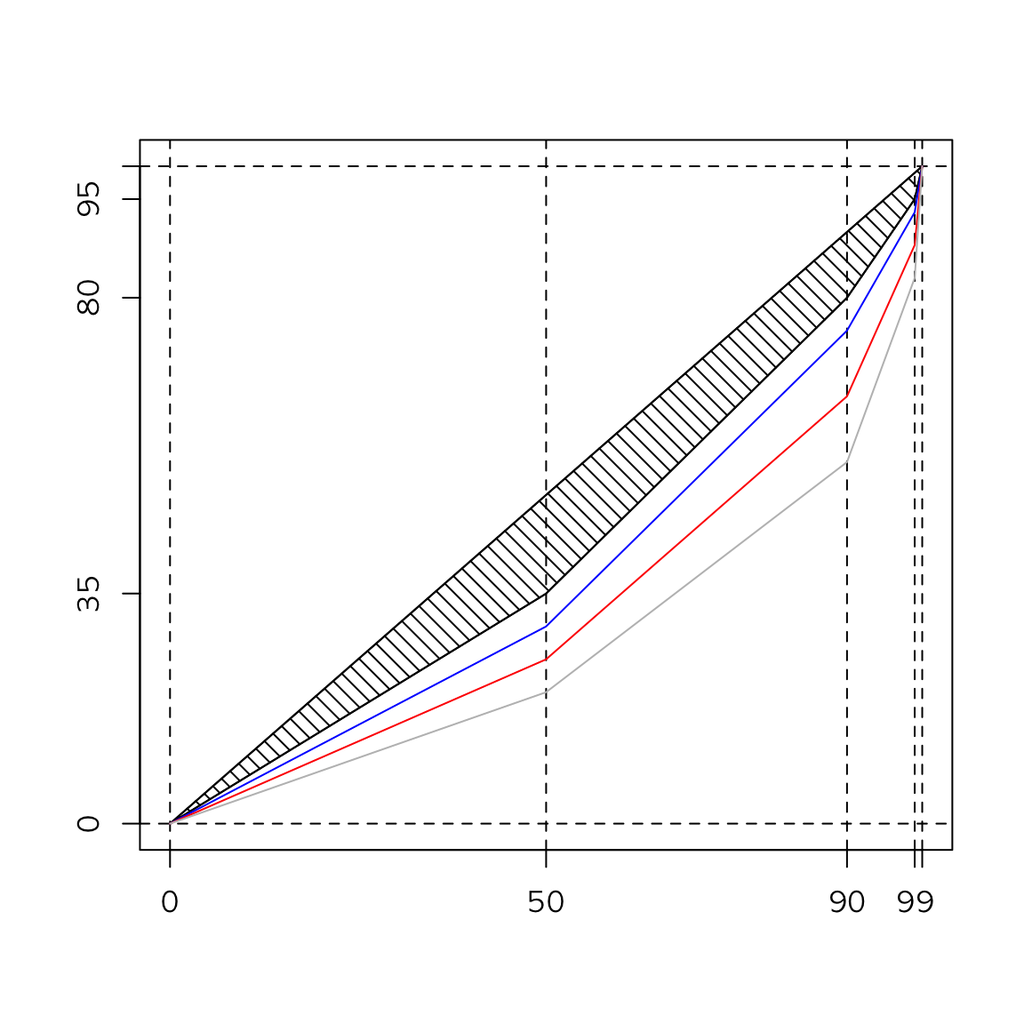

```r
plot(x = x, y = y, type="l", ann=FALSE, xaxt="n", yaxt="n")
axis(side = 1, at = x, labels = paste(x*100))
axis(side = 2, at = y, labels = paste(y*100))
lines(x = x, y = x)
abline(v = x, h = c(0, 1), lty=2)
polygon(x = c(x, 0), y = c(y, 0), density = 15, angle = 135)
lines(x = x, y = piketty.labor.cum[ , 2], col="blue")
lines(x = x, y = piketty.labor.cum[ , 3], col="red")
lines(x = x, y = piketty.labor.cum[ , 4], col="grey")
```

`legend()` 와 `title()` 로 마무리짓는다.

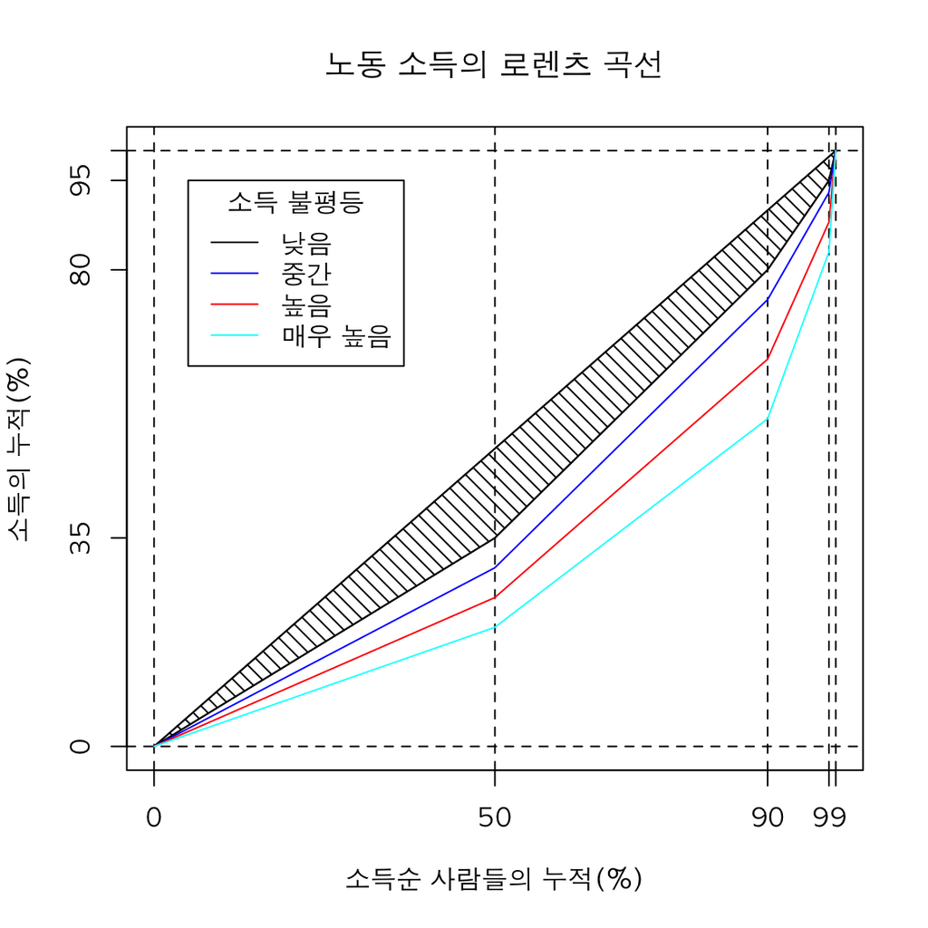

```r
plot(x = x, y = y, type="l", ann=FALSE, xaxt="n", yaxt="n")
axis(side = 1, at = x, labels = paste(x*100))
axis(side = 2, at = y, labels = paste(y*100))
lines(x = x, y = x)
abline(v = x, h = c(0, 1), lty=2)
polygon(x = c(x, 0), y = c(y, 0), density = 15, angle = 135)
lines(x = x, y = piketty.labor.cum[ , 2], col="blue")
lines(x = x, y = piketty.labor.cum[ , 3], col="red")
lines(x = x, y = piketty.labor.cum[ , 4], col="cyan")
title(main = "노동 소득의 로렌츠 곡선", xlab = "소득순 사람들의 누적(%)", ylab = "소득의 누적(%)")
legend(x = 0.05, y = 0.95, legend=c("낮음", "중간", "높음", "매우 높음"), lty = 1, col = c("black", "blue", "red", "cyan"), title="소득 불평등")
```

지금까지의 과정을 잘 살펴보면 소득순 사람들의 누적분포와 이에 따른 소득의 누적분포를 각각 $x$와 $y$로 입력하면 로렌츠 곡선을 그리고 평등선과의 차이를 빗금으로 표시할 수도 있다는 것을 알 수 있다. 이를 함수로 나타낸 것이 `lorenz()`이다. 코드를 살펴보면,

```r
lorenz
```

```
## function (x,y)
## {
##     plot(x = x, y = y, type = "l", ann = FALSE, xaxt = "n", yaxt = "n")
##     axis(side = 1, at = x, labels = paste(x*100))
##     axis(side = 2, at = y, labels = paste(y*100))
##     lines(x = x, y = x)
##     abline(v = x, h = c(0, 1), lty = 2)
##     polygon(x = c(x, 0), y = c(y, 0), density = 15, angle = 135)
## }
```

이제 `lorenz()` 함수를 이용하여 자본소득의 로렌츠 곡선들을 그려보자.

```r
piketty.co.cum<-apply(piketty.co[, 2:6], 2, cumsum)
piketty.co.cum
```

```
##    Low Medium Med.High High Very.High
## 1 0.00    0.0     0.00 0.00      0.00
## 2 0.25    0.1     0.05 0.05      0.05
## 3 0.70    0.5     0.40 0.30      0.10
## 4 0.90    0.8     0.75 0.65      0.50
## 5 1.00    1.0     1.00 1.00      1.00
```

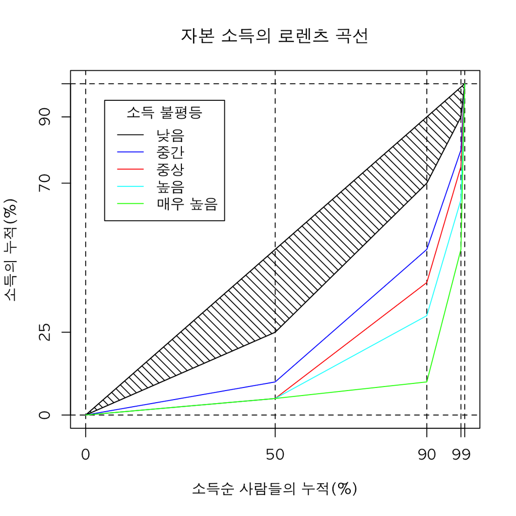

```r
y<-piketty.co.cum[, 1]
lorenz(x, y)
lines(x = x, y = piketty.co.cum[ , 2], col="blue")
lines(x = x, y = piketty.co.cum[ , 3], col="red")
lines(x = x, y = piketty.co.cum[ , 4], col="cyan")
lines(x = x, y = piketty.co.cum[ , 5], col="green")
title(main = "자본 소득의 로렌츠 곡선", xlab = "소득순 사람들의 누적(%)", ylab = "소득의 누적(%)")
legend(x = 0.05, y = 0.95, legend=c("낮음", "중간", "중상", "높음", "매우 높음"), lty = 1, col = c("black", "blue", "red", "cyan", "green"), title="소득 불평등")
```

총소득의 로렌츠 곡선들도 같은 방법으로 그릴 수 있다.

```r
piketty.total.cum<-apply(piketty.total[, 2:5], 2, cumsum)
piketty.total.cum
```

```
##    Low Medium High Very.High
## 1 0.00   0.00  0.0      0.00
## 2 0.30   0.25  0.2      0.15
## 3 0.75   0.65  0.5      0.40
## 4 0.93   0.90  0.8      0.75
## 5 1.00   1.00  1.0      1.00
```

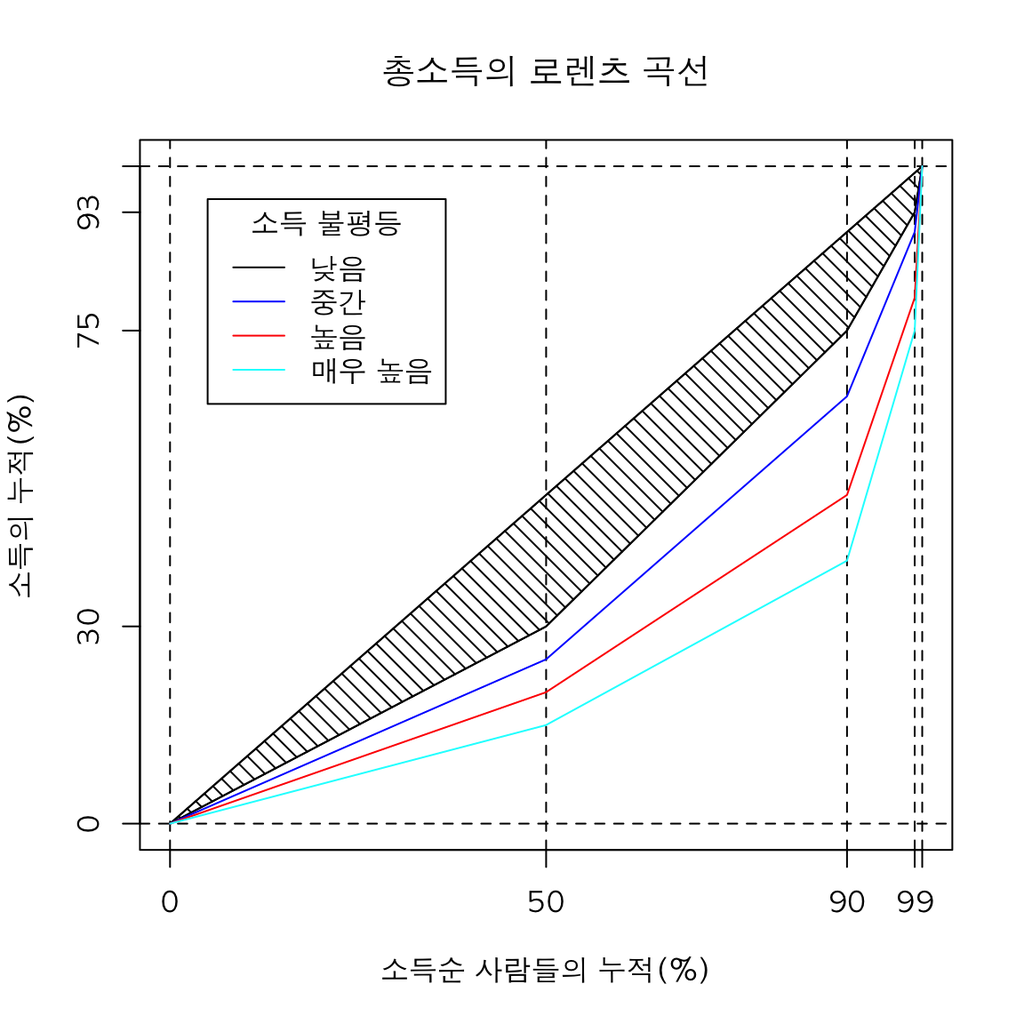

```r
y<-piketty.total.cum[, 1]
lorenz(x, y)
lines(x = x, y = piketty.total.cum[ , 2], col="blue")
lines(x = x, y = piketty.total.cum[ , 3], col="red")
lines(x = x, y = piketty.total.cum[ , 4], col="cyan")
title(main = "총소득의 로렌츠 곡선", xlab = "소득순 사람들의 누적(%)", ylab = "소득의 누적(%)")
legend(x = 0.05, y = 0.95, legend=c("낮음", "중간", "높음", "매우 높음"), lty = 1, col = c("black", "blue", "red", "cyan"), title="소득 불평등")
```

평등선과 소득누적곡선과의 차이를 나타내는 gini계수는 결국 면적 계산임을 알 수 있다. gini계수는 $\frac{빗금친 면적}{1/2}=2\times{빗금친 면적}$ 으로 주어지기 때문에 각 삼각형과 사다리꼴들의 면적을 계산하면서 2로 나누어 줄 필요가 없게 된다.

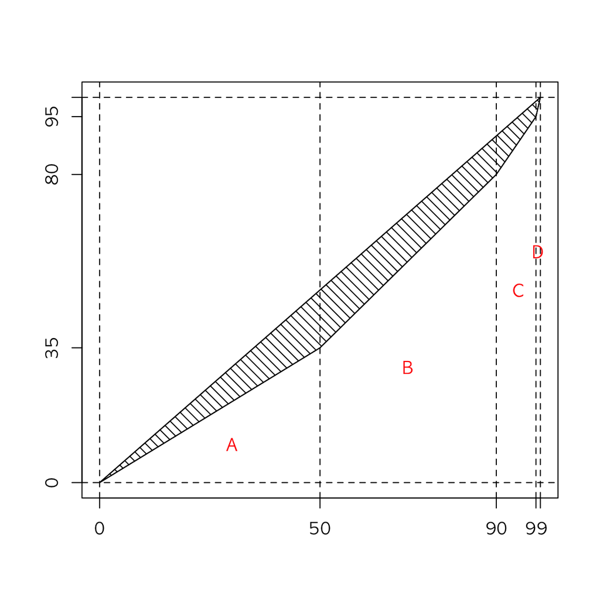

```r
lorenz(x = x, y = cumsum(piketty.labor$Low))
text(x=c(0.3, 0.7, 0.95, 0.995), y=c(0.1, 0.3, 0.5, 0.6), labels=c("A", "B", "C", "D"), col="red")
```

A, B, C, D의 면적을 합해서 2배를 해 주면 되기 때문에 2로 나눌 필요 없이 A면적의 2배는 `(y[1] + y[2]) * (x[2] - x[1])`, B면적의 2배는 `(y[2] + y[3])*(x[3] - x[2])`, C면적의 2배는 `(y[3] + y[4]) * (x[4] - x[3])`, D면적의 2배는 `(y[4] + y[5]) * (x[5] - x[4])`로 주어진다. `x[1]`과 `y[1]`이 모두 0이지만 규칙성을 파악하기 쉽도록 집어넣었다. 따라서 x-벡터의 길이보다 하나 적은 갯수의 사다리꼴들의 합을 구하는 문제로 귀착된다. 이 때 i-번째 사다리꼴 면적의 2배는 `(y[i] + y[i + 1])*(x[i + 1] - x[i])`로 주어지게 된다. 이들의 합을 구해서 1에서 빼주면 된다.

따라서 다음 코드가 나온다.

```r
gini
```

```
## function(x,y)
## {
##     n<-length(x)
##     i<-1:(n - 1)
##     s<-sum((y[i] + y[i + 1])*(x[i + 1] - x[i]))
##     s<-1 - s
##     return(s)
## }
```

`gini()`함수를 이용하여 노동소득, 자본소득, 총소득에 나타난 각 경우에 대한 Gini계수는 다음과 같이 구할 수 있다. 노동소득의 각 경우에 지니계수들은,

```r
apply(piketty.labor.cum, 2, gini, x = x)
```

```
##       Low    Medium      High Very.High
##    0.1880    0.2595    0.3585    0.4575
```

로 계산되고, 자본소득의 각 경우에 지니계수들은,

```r
apply(piketty.co.cum, 2, gini, x = x)
```

```
##       Low    Medium  Med.High      High Very.High
##     0.332     0.575     0.674     0.733     0.846
```

이고, 총소득의 각 경우에 지니계수들은,

```r
apply(piketty.total.cum, 2, gini, x = x)
```

```
##       Low    Medium      High Very.High
##    0.2595    0.3565    0.4850    0.5840
```

로 계산되어 자본소득의 경우 불평등이 매우 심한 경우에는 지니계수가 0.8을 넘기도 한다는 것을 알 수 있다.